# Predictive Modeling for Wildfire Damage Risk

## Project Overview

This project focuses on building and evaluating predictive models to estimate the risk of severe structure damage caused by wildfires, using data from CAL FIRE.

The analysis follows a structured machine learning workflow, including:

- Data preparation and feature selection
- Model training using multiple algorithms
- Model evaluation and comparison
- Iterative improvements based on insights

The dataset used in this project is derived from a subset of CAL FIRE damage inspection records, where the target variable represents whether a structure experienced severe damage ("Destroyed (>50%)") or not.

# Setup

## Import packages

```python
import pandas as pd
import numpy as np
import json
import matplotlib.pyplot as plt
import matplotlib.colors as mcolors
import seaborn as sns
import math
import itertools
import geopandas as gpd
import geodatasets
from scipy import stats
from scipy.stats import chi2_contingency, pointbiserialr
from shapely.geometry import Point
from sklearn import metrics
from sklearn.metrics import accuracy_score, precision_score, recall_score, f1_score, confusion_matrix, classification_report, make_scorer, roc_auc_score
from sklearn.linear_model import LinearRegression, LogisticRegression
from sklearn.model_selection import KFold, train_test_split, cross_validate, cross_val_score
from sklearn.ensemble import RandomForestClassifier
from sklearn.preprocessing import StandardScaler
from sklearn.tree import plot_tree

# Allows plots to appear directly in the notebook.
%matplotlib inline
pd.set_option('display.max_columns', None)
```

## Self-defined functions

### `summarize_columns`

```python
def summarize_columns(input_df):
    """
    Summarizes basic metadata for each column in a DataFrame.

    For each column, this function reports:
        - Column name
        - Number of unique values
        - Data type
        - First example value
        - Percentage of missing values

    Args:
        1. input_df (pd.DataFrame): The DataFrame to be summarized.

    Returns:
        pd.DataFrame: A summary table containing metadata for each column.
    """
    table_info = []
    for col in input_df:
        table_info_row = []
        table_info_row.append(col)
        table_info_row.append(input_df[col].nunique())
        table_info_row.append(input_df[col].dtype)
        table_info_row.append(input_df[col].iloc[0])
        table_info_row.append(round(input_df[col].isna().sum() / input_df.shape[0]*100,2))

        table_info.append(table_info_row)
    res = pd.DataFrame(table_info, columns=['col_name', 'unique_values', 'dtype', 'example', 'missing%'])

    return res
```

### `analyze_continuous_feature`

```python
def analyze_continuous_vs_damage(input_df, input_col):
    """
    Performs statistical tests and correlation analysis between a numeric feature and the binary damage outcome.

    - Converts the 'damage' column to a binary numeric representation.
    - Computes point-biserial correlation between the given numeric feature and damage.
    - Conducts Mann-Whitney U test (median) and Welch’s t-test (mean) between damage groups.
    - Prints significance and strength of the relationships.

    Args:
        1. input_df (pd.DataFrame): The input DataFrame.
        2. input_col (str): Name of the numeric feature to be evaluated.

    Returns:
        None
    """
    print(input_col)
    input_df["damage_numeric"] = input_df['damage'].map({"No Damage": 0, "Destroyed (>50%)": 1})

    corr, p_value_corr = pointbiserialr(input_df["damage_numeric"], input_df[input_col])
    print(f'Correlation between {input_col} and Damage: {corr:.3f}, p-value: {p_value_corr:.3f}')

    group1 = input_df[input_df['damage'] == "Destroyed (>50%)"][input_col]
    group2 = input_df[input_df['damage'] == "No Damage"][input_col]

    u_stat, p_value_mann = stats.mannwhitneyu(group1, group2, alternative='two-sided')
    print(f'U-statistic: {u_stat}, p-value: {p_value_mann:.3f}')

    t_stat, p_value_ttest = stats.ttest_ind(group1, group2, equal_var=False)
    print(f'T-statistic: {t_stat}, p-value: {p_value_ttest:.3f}')

    print()
    print('p = 0.05')
    if p_value_corr < 0.05:
        print(f"🌟Significant relationship between {input_col} and Damage - ", end="")
        if abs(corr) > 0.5:
            print(f'Strong correlation ({corr:.3f})')
        elif abs(corr) > 0.3:
            print(f'Moderate correlation ({corr:.3f})')
        else:
            print(f'Week correlation ({corr:.3f})')
    else:
        print("No significant relationship")

    if p_value_mann < 0.05:
        print("🌟Significant difference in median values.")
    else:
        print("No significant difference in median values.")

    if p_value_ttest < 0.05:
        print("🌟Significant difference in mean values")
    else:
        print("No significant difference in mean values")


def plot_continuous_by_damage(input_df, input_col):
    """
    Visualizes the distribution of a numeric feature across damage categories.

    - Generates three subplots:
        1. Boxplot (filtered to exclude outliers using 1.5 * IQR rule)
        2. Histogram showing count distribution
        3. Histogram showing percentage distribution

    Args:
        1. input_df (pd.DataFrame): The input DataFrame.
        2. input_col (str): Name of the numeric feature to visualize.

    Returns:
        None
    """
    colors = ['salmon', 'gray']
    fig, axes = plt.subplots(1, 3, figsize=(18, 4))
    q3 = input_df[input_col].quantile(0.75)
    q1 = input_df[input_col].quantile(0.25)
    iqr = q3 - q1
    filtered_df = input_df[(input_df[input_col] <= q3 + 1.5 * iqr) & (input_df[input_col] >= q1 - 1.5 * iqr)]

    custom_palette = {"Destroyed (>50%)": "salmon", "No Damage": "gray"}

    # Left boxplot (counts)
    sns.boxplot(
        data=filtered_df,
        x="damage",
        y=input_col,
        hue="damage",
        palette=custom_palette,
        ax=axes[0]
    )
    axes[0].set_title(f"Filtered {input_col} (exclude 1.5 * IQR outliers)")
    axes[0].set_xlabel("")

    # Middle histogram (counts)
    set1 = input_df[input_df['damage'] == 'Destroyed (>50%)'][input_col]
    set2 = input_df[input_df['damage'] == 'No Damage'][input_col]
    bins = np.histogram_bin_edges(np.concatenate([set1, set2]), bins=10)

    axes[1].hist(set1, bins=bins, color=colors[0], label='Destroyed (>50%)', alpha=0.7)
    axes[1].hist(set2, bins=bins, color=colors[1], label='No Damage', alpha=0.7)

    axes[1].set_title(f'{input_col} (counts)')
    axes[1].set_ylabel('Records')
    axes[1].legend(loc='upper left')

    axes[2].hist(set1, weights=np.ones(len(set1)) / len(set1), bins=bins, color=colors[0], label='Destroyed (>50%)', alpha=0.7)
    axes[2].hist(set2, weights=np.ones(len(set2)) / len(set2), bins=bins, color=colors[1], label='No Damage', alpha=0.7)

    axes[2].set_title(f'{input_col} (percentage)')
    axes[1].set_ylabel('Percentage')
    axes[2].legend(loc='upper left')

    # plt.tight_layout()
    plt.show()
    print()
```

```python
def analyze_continuous_feature(input_df, input_col):
    """
    Wrapper function to perform both statistical analysis and visual comparison
    for a numeric feature in relation to the damage outcome.

    Calls:
        - analyze_continuous_vs_damage(input_df, input_col)
        - plot_continuous_by_damage(input_df, input_col)

    Args:
        1. input_df (pd.DataFrame): The input DataFrame.
        2. input_col (str): Name of the numeric feature to analyze and plot.

    Returns:
        None
    """
    # Plot boxplots and histograms with showing corr and u-test and t-test values for numeric columns
    analyze_continuous_vs_damage(input_df, input_col)
    plot_continuous_by_damage(input_df, input_col)
```

### `analyze_categorical_feature`

```python
def cramers_v(chi2, n, r, c):
    """Compute Cramér's V for categorical feature association"""
    return np.sqrt(chi2 / (n * min(r - 1, c - 1)))

def analyze_categorical_vs_damage(input_df, input_col):
    """
    Performs Chi-squared test and calculates Cramér's V to assess the association
    between a categorical feature and the binary damage outcome.

    Args:
        1. input_df (pd.DataFrame): The input DataFrame.
        2. input_col (str): The name of the categorical feature to test.

    Returns:
        None
    """
    tmp = input_df[input_df[input_col] != "Unknown"]
    contingency_table = pd.crosstab(tmp[input_col], tmp["damage"])

    # Compute Chi-Square test
    chi2, _, _, _ = chi2_contingency(contingency_table)

    # Calculate Cramér's V
    n = contingency_table.sum().sum()  # Total sample size
    r, c = contingency_table.shape
    cramers_v_value = cramers_v(chi2, n, r, c)

    # Print results
    print(f"Feature: {input_col}")

    # Interpretation
    if cramers_v_value > 0.5:
        print(f"👑 Very strong association with Damage (Cramér's V:{cramers_v_value:.3f})")
    elif cramers_v_value > 0.3:
        print(f"🌟 Strong association with Damage (Cramér's V:{cramers_v_value:.3f})")
    elif cramers_v_value > 0.2:
        print(f"✅ Moderate association with Damage (Cramér's V:{cramers_v_value:.3f})")
    else:
        print(f"Weak association with damage severity (Cramér's V:{cramers_v_value:.3f})")

def plot_categorical_by_damage(input_df, input_col):
    """
    Visualizes the distribution of damage levels across categories of a given feature.

    Creates a horizontal stacked bar chart where:
    - Each bar represents a category.
    - Proportion and count of each damage type are labeled.
    - A reference line at 0.5 is shown to highlight "high-risk" threshold.

    Args:
        1. input_df (pd.DataFrame): The input DataFrame.
        2. input_col (str): The name of the categorical feature to visualize.

    Returns:
        None
    """
    custom_colors = ["salmon", "gray"]  # Example: salmon for destroyed, gray for no damage
    custom_cmap = mcolors.ListedColormap(custom_colors)
    cross_tab = pd.crosstab(input_df[input_col], input_df['damage'], normalize="index")
    cross_tab = cross_tab.sort_values(by="Destroyed (>50%)", ascending=True)
    cross_tab_counts = pd.crosstab(input_df[input_col], input_df['damage']).loc[cross_tab.index]

    fig, ax = plt.subplots(figsize=(10, 5))
    bars = cross_tab.plot(kind='barh', stacked=True, colormap=custom_cmap, ax=ax, edgecolor='black', alpha=0.7)

    for container, (damage_type, count_col) in zip(bars.containers, zip(cross_tab.columns, cross_tab_counts.columns)):
        for rect, count_value in zip(container, cross_tab_counts[count_col]):
            width = rect.get_width()
            if width > 0.05:
                x_pos = rect.get_x() + width / 2
                y_pos = rect.get_y() + rect.get_height() / 2
                ax.text(x_pos, y_pos, f"{count_value} ({width:.1%})", ha='center', va='center', fontsize=10, color="black")

    ax.axvline(x=0.5, linestyle='--', color='red', linewidth=1.5, alpha=0.8)
    ax.legend(title="Damage Type", bbox_to_anchor=(1.05, 1), loc='upper left', borderaxespad=0)
    plt.title(input_col)
    plt.show()
```

```python
def analyze_categorical_feature(input_df, input_col):
    """
    Wrapper function to perform both statistical test and visualization
    for a categorical feature in relation to damage outcome.

    Calls:
        - analyze_categorical_vs_damage(input_df, input_col)
        - plot_categorical_by_damage(input_df, input_col)

    Args:
        1. input_df (pd.DataFrame): The input DataFrame.
        2. input_col (str): The name of the categorical feature to analyze.

    Returns:
        None
    """
    # Plot barplots with showing Cramér's V for categorical feature association
    analyze_categorical_vs_damage(input_df, input_col)
    plot_categorical_by_damage(input_df, input_col)
```

### `encode_features`

```python
def encode_features(input_df, input_features, drop_first):
    """
    Transforms input features by one-hot encoding categorical variables
    and standardizing numerical (continuous) ones.

    For each feature:
    - If categorical (dtype 'category' or 'bool'): applies one-hot encoding
      - Optionally drops the first dummy column to avoid multicollinearity
    - If numerical: standardizes using StandardScaler
    - Keeps track of original-to-transformed column mappings and dropped dummy columns

    Args:
        1. input_df (pd.DataFrame): Original input DataFrame.
        2. input_features (list): List of feature names to transform.
        3. drop_first (bool): Whether to drop the first dummy variable for each categorical feature.

    Returns:
        1. encoded_df (pd.DataFrame): Final encoded and standardized DataFrame.
        2. drop_col_df (pd.DataFrame): Information on dropped dummy columns (if any).
        3. mapping_df (pd.DataFrame): Mapping from original features to encoded features.
    """
    encoded_df = pd.DataFrame()
    drop_col_records = []
    mapping_records = []

    for feature in input_features:
        if input_df[feature].dtype.name in ['category', 'bool']:
            dummies = pd.get_dummies(input_df[feature], prefix=feature, prefix_sep='_')

            # Record mapping for each dummy column
            for dummy_col in dummies.columns:
                mapping_records.append({'original_feature': feature, 'feature': dummy_col})

            # Drop first dummy column if required
            if drop_first:
                dropped_col = dummies.columns[0]
                true_cases = dummies[dropped_col].sum()
                drop_col_records.append({
                    'original_feature': feature,
                    'baseline_category': dropped_col,
                    'true_cases': true_cases
                })
                dummies = dummies.drop(columns=[dropped_col])

            encoded_df = pd.concat([encoded_df, dummies], axis=1)
        else:
            # continuous data
            scaler = StandardScaler()
            standardized_result = scaler.fit_transform(input_df[[feature]])
            standardized_df = pd.DataFrame(standardized_result, columns=[feature])
            encoded_df = pd.concat([encoded_df, standardized_df], axis=1)
            mapping_records.append({'original_feature': feature, 'feature': feature})

    drop_col_df = pd.DataFrame(drop_col_records)
    mapping_df = pd.DataFrame(mapping_records)

    return encoded_df, drop_col_df, mapping_df
```

### `encode_target`

```python
def encode_target(input_y):
    """
    Encodes the target variable `damage` into binary values.

    - Maps 'No Damage' → 0
    - Maps all other values (e.g., 'Destroyed (>50%)') → 1

    Args:
        1. input_y (pd.DataFrame): A DataFrame containing the 'damage' column.

    Returns:
        np.ndarray: Binary-encoded array of target values.
    """
    return np.where(input_y['damage'] == 'No Damage', 0, 1)
```

### `gen_model_coefficients`

```python
def gen_model_coefficients(input_coef, input_features, feature_mapping_df, coef_name='coef'):
    """
    Generates a DataFrame showing the importance / coefficient value of each feature in a linear model.

    Args:
        1. input_coef (array-like): Model coefficients or model importance. If 2D (e.g., shape (1, n_features)), the first row is used.
        2. input_features (list-like): List of feature names corresponding to the coefficients (e.g., X_train.columns).
        3. feature_mapping_df (pd.DataFrame): A DataFrame with 'original_feature' and 'feature' columns,
                                              used to map dummy variables back to their original features.
        4. coef_name (str): The name to give to the coefficient column in the output (default = 'coef').

    Returns:
        1. pd.DataFrame: A DataFrame sorted by importance with columns:
                        ['original_feature', 'feature', coef_name]
    """
    # Flatten if 2D
    if len(input_coef.shape) > 1:
        input_coef = input_coef[0]

    # Create coefficients DataFrame
    coef_df = pd.DataFrame({
        'feature': input_features,
        coef_name: np.round(input_coef, 4)
    })

    # Merge with mapping
    coef_df = coef_df.merge(feature_mapping_df, on='feature', how='left')

    # Reorder columns
    coef_df = coef_df[['original_feature', 'feature', coef_name]]

    # Sort
    coef_df = coef_df.sort_values(['original_feature', coef_name], ascending=False).reset_index(drop=True)

    return coef_df
```

### `gen_prediction_comparison`

```python
def gen_prediction_comparison(y_actual, y_pred, set_type, threshold=False):
    """
    Combines actual and predicted target values into a single DataFrame for comparison.

    Optionally supports thresholding for regression outputs to convert them into binary classes.

    Args:
        1. y_actual (pd.Series or array-like): Actual target values.
        2. y_pred (pd.Series or array-like): Predicted values.
        3. set_type (str): A label to indicate the dataset type (e.g., "train", "test").
        4. threshold (float or bool, optional): If provided, converts predictions into binary classes using this threshold.
                                                Use for regression models only. Default is False.

    Returns:
        pd.DataFrame: A DataFrame with columns for actual, predicted, and optionally classified predictions.
    """
    result = pd.DataFrame({f'y_{set_type}_actual': y_actual, f'y_{set_type}_pred': y_pred})
    if threshold != False:
        result[f'y_{set_type}_pred_class'] = np.where(result[f'y_{set_type}_pred'] < threshold, 0, 1)
    return result
```

### `classification_evaluation`

```python
def classification_evaluation(y_actual, y_pred):
    """
    Prints a full evaluation report for classification results, including:

    - Accuracy
    - Precision
    - Recall
    - F1 score
    - Confusion matrix
    - Classification report

    Args:
        1. y_actual (array-like): Ground truth binary labels.
        2. y_pred (array-like): Predicted binary labels from the model.

    Returns:
        None. Prints the evaluation to stdout.
    """
    print("Accuracy Score :", round(accuracy_score(y_actual, y_pred), 3))
    print("Precision Score:", round(precision_score(y_actual, y_pred), 3))
    print("Recall Score   :", round(recall_score(y_actual, y_pred), 3))
    print("F1 Score       :", round(f1_score(y_actual, y_pred), 3))
    confusion_matrix_res = pd.DataFrame(confusion_matrix(y_actual, y_pred))
    confusion_matrix_res.columns=['Predicted: No Damage (0)', 'Predicted: Destroyed (1)']
    confusion_matrix_res.index=['Actual: No Damage (0)', 'Actual: Destroyed (1)']
    print()
    print("Confusion Matrix:")
    display(confusion_matrix_res)
    print()
    print("Classification Report:")
    print(classification_report(y_actual, y_pred, zero_division=1))
```

### `gen_cross_validation_performance`

```python
def gen_cross_validation_performance(model, model_name, input_X, input_y, n_splits):
    """
    Run K-Fold cross-validation on the given model and return average classification metrics as a DataFrame.

    Evaluation metrics include:
    - Accuracy
    - Precision
    - Recall
    - F1 score

    Args:
        1. model (sklearn classifier): The classification model to evaluate.
        2. model_name (str): A string name to identify the model in the result.
        3. input_X (pd.DataFrame or np.ndarray): Feature matrix.
        4. input_y (pd.Series or np.ndarray): Target variable.
        5. n_splits (int): Number of folds for K-Fold cross-validation.

    Returns:
        pd.DataFrame: A single-row DataFrame containing model name, fold count,
                      number of features, and averaged evaluation metrics.
    """
    cv = KFold(n_splits=n_splits, shuffle=True, random_state=42)

    # Define scoring metrics
    scoring = {
        'accuracy': make_scorer(accuracy_score),
        'precision': make_scorer(precision_score),
        'recall': make_scorer(recall_score),
        'f1': make_scorer(f1_score)
    }

    results = cross_validate(model, input_X, input_y, cv=cv, scoring=scoring)
    perf_df = pd.DataFrame({
        'model': [model_name],
        'folds': [n_splits],
        'features': [input_X.shape[1]],
        'avg_acuracy_score': [round(np.mean(results['test_accuracy']), 3)],
        'avg_precision_score': [round(np.mean(results['test_precision']), 3)],
        'avg_recall_sore': [round(np.mean(results['test_recall']), 3)],
        'avg_f1_score': [round(np.mean(results['test_f1']), 3)]
    }
    )
    return perf_df
```

### `compare_cv_splits`

```python
def compare_cv_splits(input_X, input_y, model, model_name, nsplits_list):
    """
    Evaluate model performance using different numbers of cross-validation folds.

    This function runs cross-validation on the given model using multiple values of `n_splits`
    to assess how the number of folds affects model performance.
    It aggregates the results into a single DataFrame for easy comparison.

    Args:
        1. input_X (pd.DataFrame): Feature matrix.
        2. input_y (pd.Series or np.array): Target vector.
        3. model (sklearn estimator): Model instance supporting `.fit()` and `.predict()`.
        4. model_name (str): Name of the model to appear in the result table.
        5. nsplits_list (list of int): A list of integers representing different fold numbers for K-Fold cross-validation.

    Returns:
        pd.DataFrame: A concatenated DataFrame containing cross-validation results
                      (accuracy, precision, recall, F1) for each value in `nsplits_list`.
    """
    all_perf_df = pd.DataFrame()
    for n_splits in nsplits_list:
        tmp_perf_df = gen_cross_validation_performance(model, model_name, input_X, input_y, n_splits)
        all_perf_df = pd.concat([all_perf_df, tmp_perf_df], axis=0)
    return all_perf_df
```

### `label_high_risk_categories`

```python
def label_high_risk_categories(input_df, input_col):
    """
    Identifies and labels high-risk categories for a given categorical feature based on damage ratio.

    This function calculates the proportion of entries labeled as 'Destroyed (>50%)'
    for each category within the specified column.
    Categories with a damage ratio greater than 0.5 are considered high risk.
    A new binary feature `is_high_risk_<input_col>` is added to the DataFrame, where True indicates that the
    original category is high risk, and False otherwise.

    Args:
        input_df (pd.DataFrame): The input DataFrame containing the original data.
        input_col (str): The name of the categorical feature to evaluate.

    Returns:
        pd.DataFrame: The modified DataFrame with the new binary high-risk column.
    """
    tmp = input_df[[input_col, 'damage']].copy()
    tmp['damage_class'] = np.where(tmp['damage'] == 'Destroyed (>50%)', 1, 0)

    damage_ratio = tmp.groupby(input_col, observed=False)['damage_class'].mean().reset_index(name='damage_ratio')

    high_risk_type = damage_ratio[damage_ratio['damage_ratio'] > 0.5][input_col]

    # Add binary feature to original df
    input_df[f'is_high_risk_{input_col}'] = input_df[input_col].isin(high_risk_type)

    return input_df
```

### `plot_feature_correlation_heatmap`

```python
def cramers_v_from_dataframe(x, y):
    """
    Calculate Cramér's V between two categorical pandas Series.

    Args:
        x (pd.Series): First categorical variable.
        y (pd.Series): Second categorical variable.

    Returns:
        float: Cramér's V statistic.
    """
    contingency_table = pd.crosstab(x, y)
    chi2, _, _, _ = chi2_contingency(contingency_table, correction=False)
    n = contingency_table.sum().sum()
    r, c = contingency_table.shape
    return cramers_v(chi2, n, r, c)
```

```python
def plot_feature_correlation_heatmap(input_df, input_features, kind="categorical"):
    """
    Plots a correlation heatmap for the selected features.

    Parameters:
        1. input_df (pd.DataFrame): The input DataFrame containing the features.
        2. input_features (list): A list of column names to include in the correlation heatmap.
                                 ❗All features in the list must be of the same type (categorical or continuous).
        3. kind (str): Type of features to analyze. Acceptable values:
                       - "categorical": computes pairwise Cramér's V between categorical features.
                       - "continuous" : computes Pearson correlation between numeric features.

    Returns:
        A Seaborn heatmap displaying pairwise feature correlations.
    """
    if kind == "categorical":
        corr_matrix = pd.DataFrame(index=input_features, columns=input_features)
        for col1 in input_features:
            for col2 in input_features:
                corr_matrix.loc[col1, col2] = cramers_v_from_dataframe(input_df[col1], input_df[col2])
        corr_matrix = corr_matrix.astype(float)
    elif kind == "continuous":
        corr_matrix = input_df[input_features].corr()
    else:
        raise ValueError("Invalid `kind`. Use 'categorical' or 'continuous'.")

    mask = np.triu(np.ones_like(corr_matrix, dtype=bool))
    plt.figure(figsize=(10, 8))
    sns.heatmap(
        corr_matrix,
        annot=True,
        cmap="coolwarm",
        fmt=".2f",
        mask=mask,
        linewidths=0.5,
        cbar_kws={"shrink": 0.8}
    )
    title = f"Feature Correlation Heatmap ({kind} variables)"
    plt.title(title, fontsize=14)
    plt.xticks(rotation=45, ha="right")
    plt.yticks(rotation=0)
    plt.show()
```

### `compare_rf_cv`

```python
def compare_rf_cv(input_feature_sets):
    """
    Compare cross-validation performance of a Random Forest classifier using different feature sets.

    This function trains and evaluates a Random Forest classifier using 5-fold cross-validation
    across multiple feature sets, and returns a combined DataFrame summarizing the performance metrics.

    Args:
        1. input_feature_sets (dict): A dictionary where:
            - keys (str): A label name for each feature set
            - values (pd.DataFrame): Feature sets (X) to be used with the same target (y).

    Returns:
        pd.DataFrame: A combined DataFrame containing the cross-validation results
                      (accuracy, precision, recall, F1) for each feature set.
    """
    rf_classifier = RandomForestClassifier(random_state=42)
    all_perf_df = gen_cross_validation_performance(rf_classifier, "RF (baseline)", X, y, 5)

    for name, X_feat in input_feature_sets.items():
        tmp_perf_df = gen_cross_validation_performance(rf_classifier, f"RF ({name})", X_feat, y, 5)
        all_perf_df = pd.concat([all_perf_df, tmp_perf_df], axis=0)

    return all_perf_df
```

### `gen_feature_versions_by_importance`

```python
def gen_feature_versions_by_importance(input_X, feature_importance_df, base_version_name):
    """
    Generate multiple feature sets by removing features below importance thresholds.
    Thresholds are automatically calculated using mean, 25th, 50th, and 75th percentile of feature importance.

    Args:
        1. input_X (pd.DataFrame): The original feature matrix.
        2. feature_importance_df (pd.DataFrame): A DataFrame with columns ['feature', 'importance'].
        3. base_version_name (str): Name of the base version in the output dictionary.

    Returns:
        dict: A dictionary with version names as keys and pruned feature DataFrames as values.
    """
    thresholds = {
        'mean': round(feature_importance_df['importance'].mean(), 3),
        '25th': round(np.quantile(feature_importance_df['importance'], 0.25), 3),
        'median': round(feature_importance_df['importance'].median(), 3),
        '75th': round(np.quantile(feature_importance_df['importance'], 0.75), 3)
    }

    feature_versions_dict = {base_version_name: input_X}
    idx = 1
    for label, value in thresholds.items():
        low_importance_features = feature_importance_df[feature_importance_df['importance'] < value]['feature'].tolist()
        version_name = f"{base_version_name}-{idx}: removed < {value} importance ({label})"
        feature_versions_dict[version_name] = input_X.drop(columns=low_importance_features)
        idx += 1

    return feature_versions_dict
```

# 1. Data Understanding and Preparation

This section focuses on preparing the dataset for predictive modeling by exploring feature relationships and selecting relevant variables based on patterns observed in the training data.

## Load the dataset

- The dataset used is the final version from the previous homework, which includes some additional features
- Before feeding the data into machine learning models, column names were renamed to snake_case for easier handling and processing and converted to correct data types

```python
df = pd.read_csv('../data/processed/cal_wildfire_final_features.csv')
df.columns
```

```
Index(['Unnamed: 0', 'OBJECTID', '* Damage',
       '* Street Type (e.g. road, drive, lane, etc.)', '* City', 'Zip Code',
       '* CAL FIRE Unit', 'County', 'Incident Start Date', '* Structure Type',
       'Structure Category', '* Roof Construction', '* Eaves',
       'Vent Screen Type', '* Exterior Siding', '* Window Pane',
       '* Deck/Porch On Grade', '* Deck/Porch Elevated',
       '* Patio Cover/Carport Attached to Structure',
       '* Fence Attached to Structure', 'Assessed Improved Value (parcel)',
       'Year Built (parcel)', 'Latitude', 'Longitude', 'Has Vent',
       'Has Vent Screen', 'Damage_numeric', 'Incident Start Month',
       'Incident Start Season', 'Incident Start Year', 'Shape Area (km2)',
       'Shape Length (km)', 'Danger Factor Score'],
      dtype='object')
```

```python
df = df.rename(columns={'* Damage': 'damage',
                        '* Street Type (e.g. road, drive, lane, etc.)': 'street_type',
                        '* City': 'city',
                        'Zip Code': 'zip_code',
                        '* CAL FIRE Unit': 'cal_fire_unit',
                        'County': 'county',
                        'Incident Start Date': 'incident_start_date',
                        '* Structure Type': 'structure_type',
                        'Structure Category': 'structure_category',
                        '* Roof Construction': 'roof_construction',
                        '* Eaves': 'eaves',
                        'Vent Screen Type': 'vent_screen_type',
                        '* Exterior Siding': 'exterior_siding',
                        '* Window Pane': 'window_pane',
                        '* Deck/Porch On Grade': 'deck/porch_on_grade',
                        '* Deck/Porch Elevated': 'deck/porch_elevated',
                        '* Patio Cover/Carport Attached to Structure': 'patio_attached',
                        '* Fence Attached to Structure': 'fence_attached',
                        'Assessed Improved Value (parcel)': 'assessed_improved_value',
                        'Year Built (parcel)': 'year_built',
                        'Latitude': 'latitude',
                        'Longitude': 'longitude',
                        'Has Vent': 'has_vent',
                        'Has Vent Screen': 'has_vent_screen',
                        'Incident Start Month': 'incident_start_month',
                        'Incident Start Season': 'incident_start_season',
                        'Incident Start Year': 'incident_start_year',
                        'Shape Area (km2)': 'shape_area_km2',
                        'Shape Length (km)': 'shape_length_km',
                        'Danger Factor Score': 'danger_factor_score'
                       })
df.columns
```

```
Index(['Unnamed: 0', 'OBJECTID', 'damage', 'street_type', 'city', 'zip_code',
       'cal_fire_unit', 'county', 'incident_start_date', 'structure_type',
       'structure_category', 'roof_construction', 'eaves', 'vent_screen_type',
       'exterior_siding', 'window_pane', 'deck/porch_on_grade',
       'deck/porch_elevated', 'patio_attached', 'fence_attached',
       'assessed_improved_value', 'year_built', 'latitude', 'longitude',
       'has_vent', 'has_vent_screen', 'Damage_numeric', 'incident_start_month',
       'incident_start_season', 'incident_start_year', 'shape_area_km2',
       'shape_length_km', 'danger_factor_score'],
      dtype='object')
```

```python
categorical_cols = ['damage', 'street_type', 'city', 'zip_code',
       'cal_fire_unit', 'county', 'structure_type',
       'structure_category', 'roof_construction', 'eaves', 'vent_screen_type',
       'exterior_siding', 'window_pane', 'deck/porch_on_grade', 'incident_start_month',
       'deck/porch_elevated', 'patio_attached', 'fence_attached',
       'has_vent', 'has_vent_screen', 'incident_start_season']
df[categorical_cols] = df[categorical_cols].astype('category')
df['incident_start_date'] = pd.to_datetime(df['incident_start_date'])
summarize_columns(df)
```

|  | col_name | unique_values | dtype | example | missing% |
| --- | --- | --- | --- | --- | --- |
| 0 | Unnamed: 0 | 9783 | int64 | 0 | 0.0 |
| 1 | OBJECTID | 9783 | int64 | 10143 | 0.0 |
| 2 | damage | 2 | category | No Damage | 0.0 |
| 3 | street_type | 13 | category | Way | 0.0 |
| 4 | city | 87 | category | Santa Rosa | 0.0 |
| 5 | zip_code | 302 | category | 95409 | 0.0 |
| 6 | cal_fire_unit | 26 | category | LNU | 0.0 |
| 7 | county | 47 | category | Sonoma | 0.0 |
| 8 | incident_start_date | 152 | datetime64[ns] | 2020-09-27 00:00:00 | 0.0 |
| 9 | structure_type | 8 | category | Single Family Residence Single Story | 0.0 |
| 10 | structure_category | 4 | category | Single Residence | 0.0 |
| 11 | roof_construction | 8 | category | Asphalt | 0.0 |
| 12 | eaves | 4 | category | Unenclosed | 0.0 |
| 13 | vent_screen_type | 6 | category | Mesh Screen <= 1/8"" | 0.0 |
| 14 | exterior_siding | 9 | category | Wood | 0.0 |
| 15 | window_pane | 4 | category | Multi Pane | 0.0 |
| 16 | deck/porch_on_grade | 4 | category | Masonry/Concrete | 0.0 |
| 17 | deck/porch_elevated | 4 | category | Wood (Includes Composite) | 0.0 |
| 18 | patio_attached | 4 | category | No Patio Cover/Carport | 0.0 |
| 19 | fence_attached | 4 | category | Non Combustible | 0.0 |
| 20 | assessed_improved_value | 7599 | int64 | 660000 | 0.0 |
| 21 | year_built | 134 | int64 | 1979 | 0.0 |
| 22 | latitude | 9779 | float64 | 38.465793 | 0.0 |
| 23 | longitude | 9782 | float64 | -122.629173 | 0.0 |
| 24 | has_vent | 3 | category | Has Vents | 0.0 |
| 25 | has_vent_screen | 3 | category | Screened | 0.0 |
| 26 | Damage_numeric | 2 | int64 | 0 | 0.0 |
| 27 | incident_start_month | 10 | category | 9 | 0.0 |
| 28 | incident_start_season | 4 | category | Fall | 0.0 |
| 29 | incident_start_year | 13 | int64 | 2020 | 0.0 |
| 30 | shape_area_km2 | 26 | int64 | 189908 | 0.0 |
| 31 | shape_length_km | 26 | int64 | 2810 | 0.0 |
| 32 | danger_factor_score | 23 | int64 | 12 | 0.0 |

## Split the dataset into two datasets

- The dataset was split into 70% training (`X_origin`) and 30% testing data (`y_origin`)
- Training: `X_train_origin`, `y_train_origin`
- Testing: `X_test_origin`, `y_test_origin`

```python
df.drop(columns=['damage']).columns
```

```
Index(['Unnamed: 0', 'OBJECTID', 'street_type', 'city', 'zip_code',
       'cal_fire_unit', 'county', 'incident_start_date', 'structure_type',
       'structure_category', 'roof_construction', 'eaves', 'vent_screen_type',
       'exterior_siding', 'window_pane', 'deck/porch_on_grade',
       'deck/porch_elevated', 'patio_attached', 'fence_attached',
       'assessed_improved_value', 'year_built', 'latitude', 'longitude',
       'has_vent', 'has_vent_screen', 'Damage_numeric', 'incident_start_month',
       'incident_start_season', 'incident_start_year', 'shape_area_km2',
       'shape_length_km', 'danger_factor_score'],
      dtype='object')
```

```python
X_origin = df.drop(columns=['OBJECTID', 'damage'])
y_origin = df[['damage']]
```

```python
# Take a third (random) data samples as test data, rest as training data
X_train_origin, X_test_origin, y_train_origin, y_test_origin = train_test_split(X_origin, y_origin, test_size=0.3, random_state=0)
```

```python
# Confirm the percentage
print(X_train_origin.shape[0] / X_origin.shape[0])
print(X_test_origin.shape[0] / X_origin.shape[0])
```

```
0.6999897781866503
0.3000102218133497
```

## Explore the relationships on the training set

### Correlations between all the continuous features

- `latitude` and `longitude` exhibit a strong negative correlation (-0.87), which, as observed in Homework 1, can be attributed to the geographical shape of California. In addition, `latitude` is negatively correlated with `incident_start_year` (-0.69), while `longitude` shows the opposite pattern. These patterns may reflect the fact that older wildfire records tend to come from the upper-left region of California, while more recent records are from the lower-right region. Whether this reflects a genuine temporal-spatial trend or is influenced by a few major wildfire events is worth further investigation.
- `shape_length_km` and `shape_area_km2` have a strong positive correlation (0.89), which is expected given the geometric relationship between length and area.

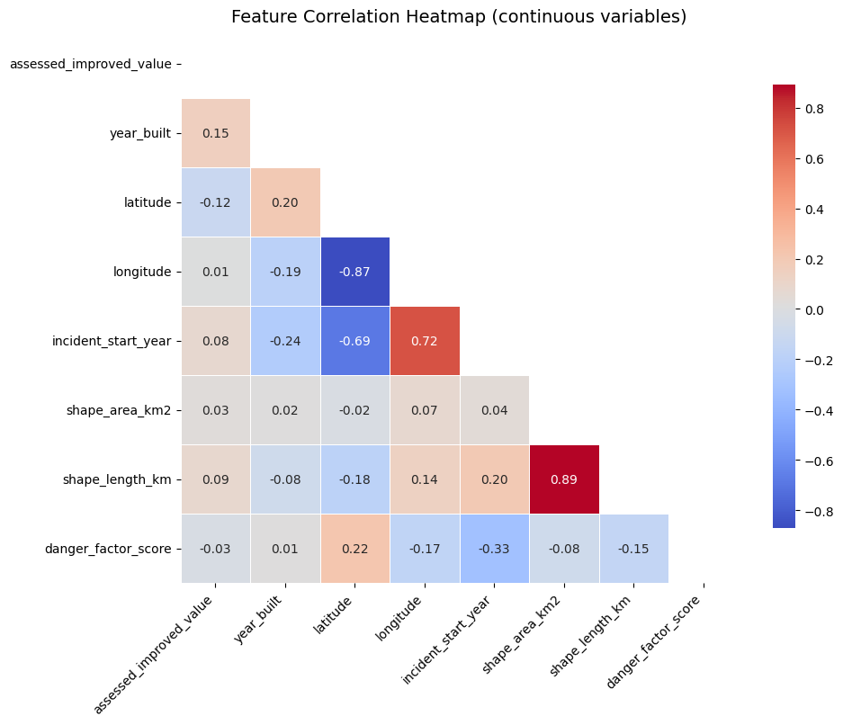

```python
continuos_features = X_train_origin.select_dtypes(['int', 'float'])
plot_feature_correlation_heatmap(X_train_origin, continuos_features.columns, 'continuous')
```

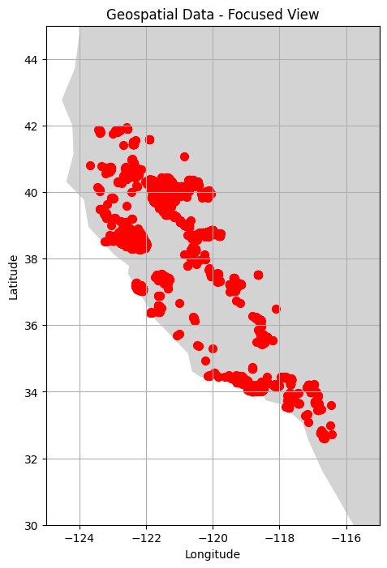

```python
# Convert to GeoDataFrame
geometry = [Point(xy) for xy in zip(continuos_features["longitude"], continuos_features["latitude"])]
gdf = gpd.GeoDataFrame(continuos_features, geometry=geometry)

# Load world map
world = gpd.read_file(geodatasets.data.naturalearth.land['url'])

# Plot
fig, ax = plt.subplots(figsize=(10, 8))
world.plot(ax=ax, color="lightgray")  # Background map
gdf.plot(ax=ax, marker="o", color="red", markersize=50)

# Set zoomed-in view (Change these values based on your area of interest)
ax.set_xlim([-125, -115])  # Longitude range
ax.set_ylim([30, 45])  # Latitude range

# Formatting
plt.title("Geospatial Data - Focused View")
plt.xlabel("Longitude")
plt.ylabel("Latitude")
plt.grid(True)

plt.show()
```

### Interaction between continuous features and target feature

Based on the histograms, boxplots, and the results from Pearson’s correlation, T-test, and Mann-Whitney U test, all analyses consistently show that the continuous features exhibit significant differences in both median and mean values. However, most correlation coefficients are quite low, suggesting that while these features may have some influence, they are not the primary drivers of fire damage severity.

In contrast, `incident_start_year` and `danger_factor_score` show moderate correlations with the target variable, indicating they may be more relevant indicators. More than 90% of incidents between 2013 and 2018 resulted in severe destruction (including the Camp Fire in 2018). However, the `danger_factor_score` is derived from a simple weighted sum of several influential features and lacks a rigorous formulation. Therefore, in future modeling, only `incident_start_year` will be retained for use.

```
assessed_improved_value
Correlation between assessed_improved_value and Damage: -0.088, p-value: 0.000
U-statistic: 4847091.5, p-value: 0.000
T-statistic: -6.95794969618906, p-value: 0.000

p = 0.05
🌟Significant relationship between assessed_improved_value and Damage - Week correlation (-0.088)
🌟Significant difference in median values.
🌟Significant difference in mean values
```

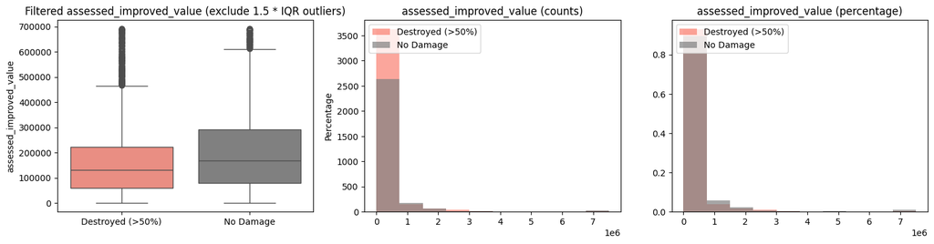

```
year_built
Correlation between year_built and Damage: -0.093, p-value: 0.000
U-statistic: 5123127.0, p-value: 0.000
T-statistic: -7.662585288101724, p-value: 0.000

p = 0.05
🌟Significant relationship between year_built and Damage - Week correlation (-0.093)
🌟Significant difference in median values.
🌟Significant difference in mean values
```

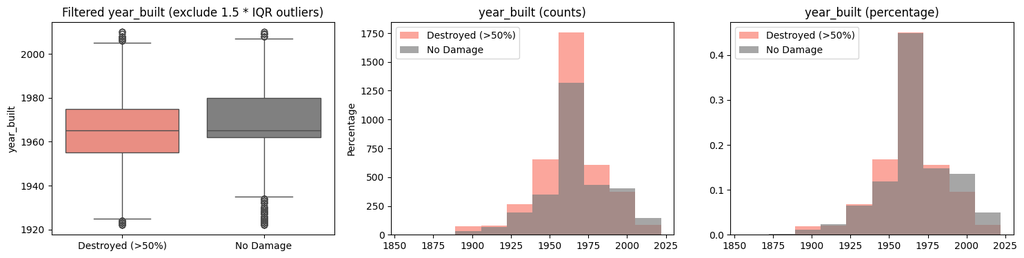

```
latitude
Correlation between latitude and Damage: 0.153, p-value: 0.000
U-statistic: 6794452.0, p-value: 0.000
T-statistic: 12.77552252598395, p-value: 0.000

p = 0.05
🌟Significant relationship between latitude and Damage - Week correlation (0.153)
🌟Significant difference in median values.
🌟Significant difference in mean values
```

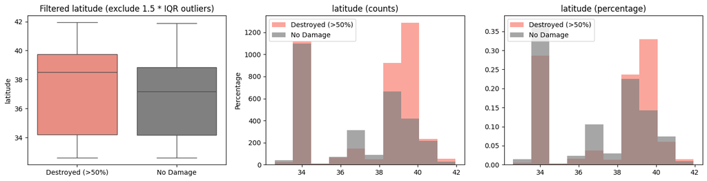

```
longitude
Correlation between longitude and Damage: -0.178, p-value: 0.000
U-statistic: 4577141.5, p-value: 0.000
T-statistic: -14.871195028803177, p-value: 0.000

p = 0.05
🌟Significant relationship between longitude and Damage - Week correlation (-0.178)
🌟Significant difference in median values.
🌟Significant difference in mean values
```

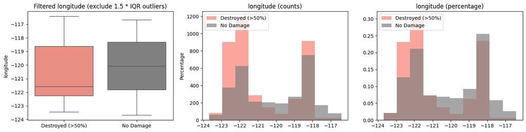

```
incident_start_year
Correlation between incident_start_year and Damage: -0.309, p-value: 0.000
U-statistic: 3488211.0, p-value: 0.000
T-statistic: -27.952871330991567, p-value: 0.000

p = 0.05
🌟Significant relationship between incident_start_year and Damage - Moderate correlation (-0.309)
🌟Significant difference in median values.
🌟Significant difference in mean values
```

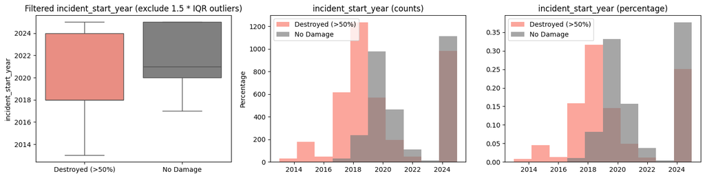

```
shape_area_km2
Correlation between shape_area_km2 and Damage: -0.129, p-value: 0.000
U-statistic: 5075387.0, p-value: 0.000
T-statistic: -9.994893203829383, p-value: 0.000

p = 0.05
🌟Significant relationship between shape_area_km2 and Damage - Week correlation (-0.129)
🌟Significant difference in median values.
🌟Significant difference in mean values
```

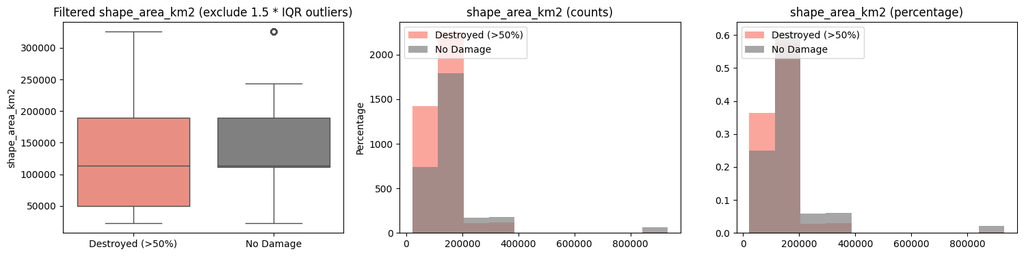

```
shape_length_km
Correlation between shape_length_km and Damage: -0.111, p-value: 0.000
U-statistic: 5180927.0, p-value: 0.000
T-statistic: -8.826815438355691, p-value: 0.000

p = 0.05
🌟Significant relationship between shape_length_km and Damage - Week correlation (-0.111)
🌟Significant difference in median values.
🌟Significant difference in mean values
```

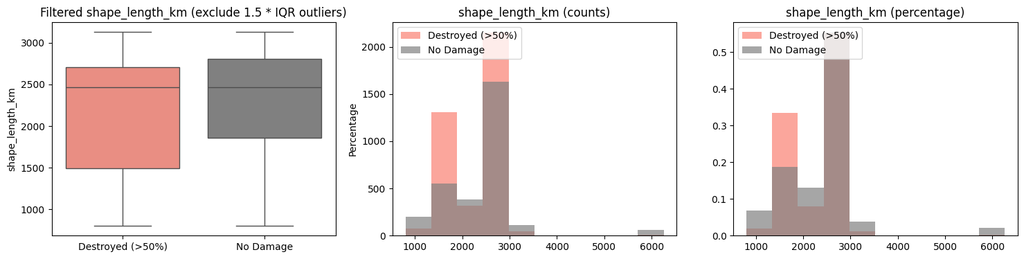

```
danger_factor_score
Correlation between danger_factor_score and Damage: 0.437, p-value: 0.000
U-statistic: 8559792.5, p-value: 0.000
T-statistic: 40.97320126331668, p-value: 0.000

p = 0.05
🌟Significant relationship between danger_factor_score and Damage - Moderate correlation (0.437)
🌟Significant difference in median values.
🌟Significant difference in mean values
```

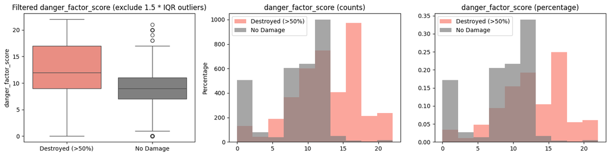

```python
train_df = pd.concat([X_train_origin, y_train_origin], axis=1)

for col in continuos_features:
    analyze_continuous_feature(train_df, col)
```

### Interaction between categorical features and target feature

Some categories have a small sample size, which may cause their severe damage rates to be influenced by extreme values, making the results less reliable. To ensure a more accurate analysis, the focus will be on categories with more than 100 cases and a severe damage rate exceeding 60%. This approach helps minimize the impact of small-sample anomalies on the conclusions.

Based on the severe damage rates, number of records, and the stength of the relationship, there are some promising categorical features:

**1. `structure_type`: Mobile Homes & Motor Homes**  
Within the "Single Residence" category, most structure types show a severe damage rate above 60%. However, Mobile Home structures (including Single, Double, and Triple Wide) stand out, with destruction rates exceeding 70%. This is likely due to the inherent characteristics of mobile homes, such as lightweight materials, weaker structural stability, and higher susceptibility to extreme weather or fire spread.

**2. `roof_construction`: Combustible, Fire Resistant, Wood, Asphalt**  
The type of roof construction plays a crucial role in fire severity:

- **Combustible**: Highly flammable, allowing fires to spread rapidly, especially under high temperatures or strong winds.
- **Wood**: Can lose structural integrity when burned, increasing the likelihood of collapse.
- **Asphalt**: May melt and contribute to the fire, especially if low-quality asphalt contains more flammable components.
- **Fire Resistant (Unexpectedly High Damage Rate!)**: Although this material is intended to resist fire, it may actually lead to severe damage due to the smoldering effect—where the roof effectively blocks external fire penetration but traps heat and smoke inside the building, leading to extremely high internal temperatures. Additionally, fire-resistant roofs may hinder firefighting efforts by blocking water access from above, which prevents firefighters from effectively extinguishing internal fires.

- **Combustible**: Fuels the fire, making it burn more intensely and harder to control.
- **Fire Resistant**: Similar to fire-resistant roofs, this material can trap heat inside and make firefighting more difficult.
- **Ignition Resistant**: Though difficult to ignite, this material may also trap heat within the structure, weakening internal support and making the fire harder to extinguish.

Notably, `Vent Screen Type` exhibited a moderate association with `damage` in the previous section. However, this correlation may have been unintentionally amplified due to the classification of "Screened" as a separate category from other screened types with different mesh sizes. Since there is little distinction between screened vents with larger or smaller mesh sizes, `Vent Screen Type` provides limited additional insight. Instead, `has_vent` and `has_vent_screen` are sufficient for assessing its impact.

**5. `incident_start_month` and `incident_start_season`: Higher Fire Severity in fall season** Both features demonstrate a moderate to strong relationship with damage severity. Notably, February, October, and November are associated with higher damage rates, which may be linked to drier weather conditions and reduced precipitation during these months. This seasonal pattern is also evident in the elevated damage levels observed in the fall. However, since `incident_start_month` and `incident_start_season` are closely related, only `incident_start_month` will be retained for further modeling to avoid redundancy.

```
Feature: structure_type
✅ Moderate association with Damage (Cramér's V:0.210)
```

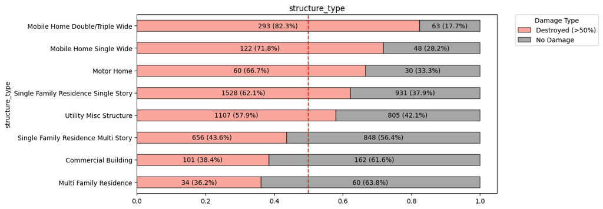

```
Feature: structure_category
Weak association with damage severity (Cramér's V:0.091)
```

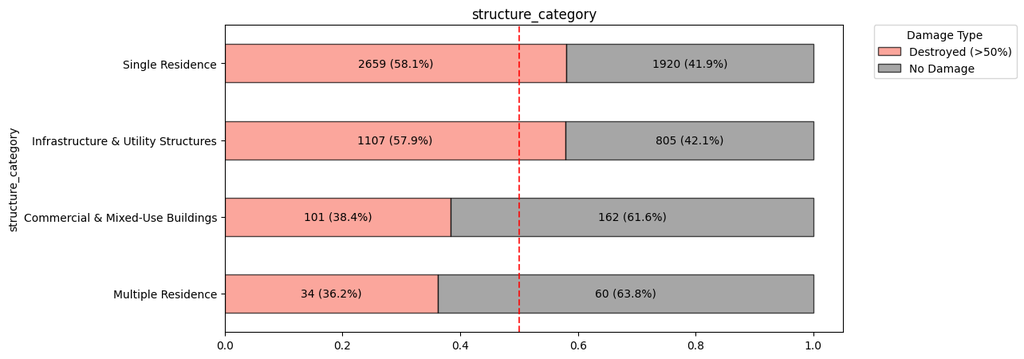

```
Feature: roof_construction
🌟 Strong association with Damage (Cramér's V:0.329)
```

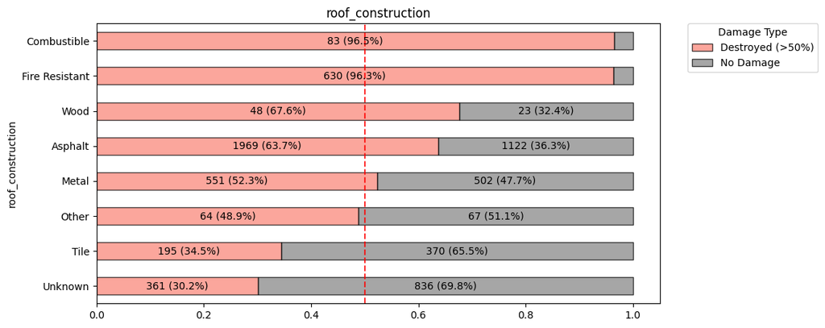

```
Feature: eaves
Weak association with damage severity (Cramér's V:0.092)
```

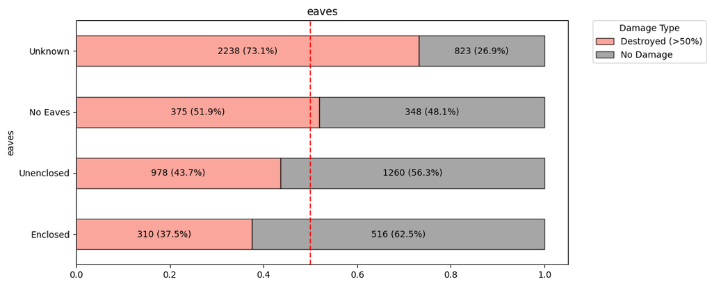

```
Feature: vent_screen_type
✅ Moderate association with Damage (Cramér's V:0.296)
```

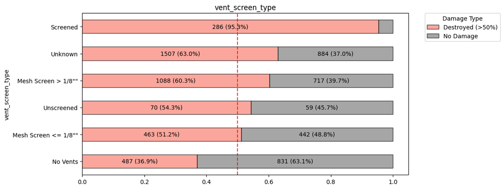

```
Feature: exterior_siding
👑 Very strong association with Damage (Cramér's V:0.547)
```

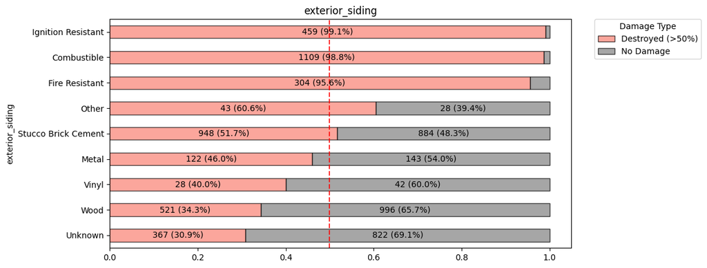

```
Feature: window_pane
Weak association with damage severity (Cramér's V:0.082)
```

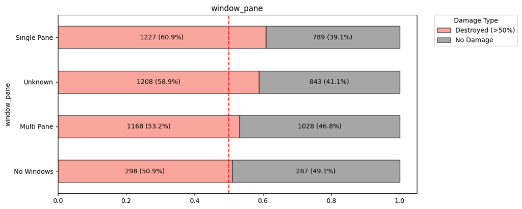

```
Feature: deck/porch_on_grade
Weak association with damage severity (Cramér's V:0.026)
```

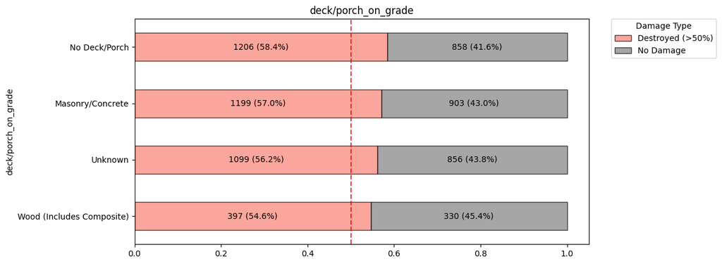

```
Feature: deck/porch_elevated
Weak association with damage severity (Cramér's V:0.115)
```

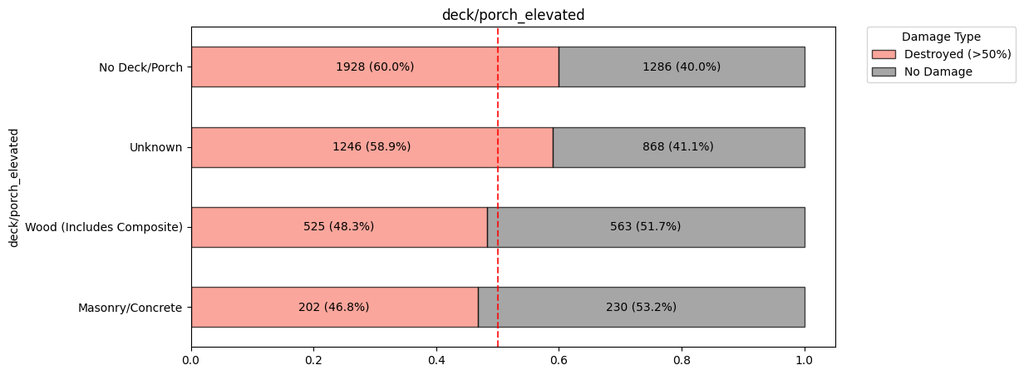

```
Feature: patio_attached
Weak association with damage severity (Cramér's V:0.035)
```

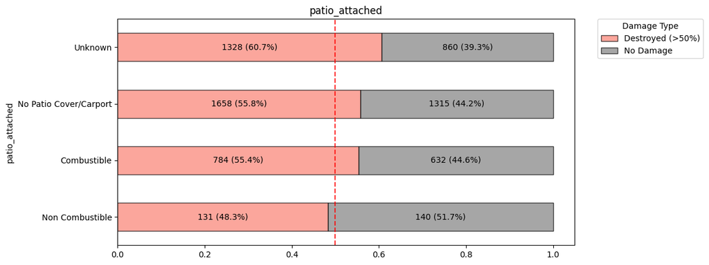

```
Feature: fence_attached
Weak association with damage severity (Cramér's V:0.128)
```

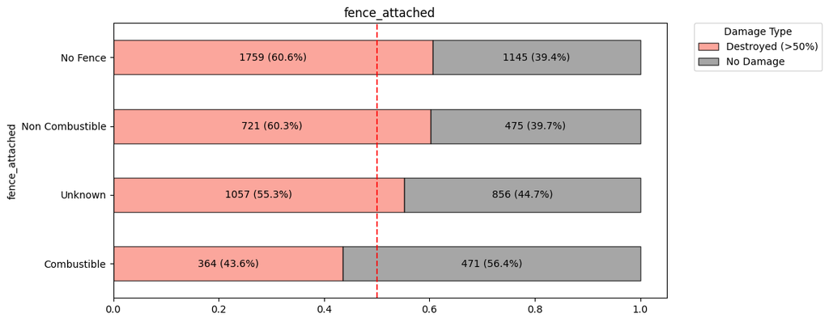

```
Feature: has_vent
✅ Moderate association with Damage (Cramér's V:0.217)
```

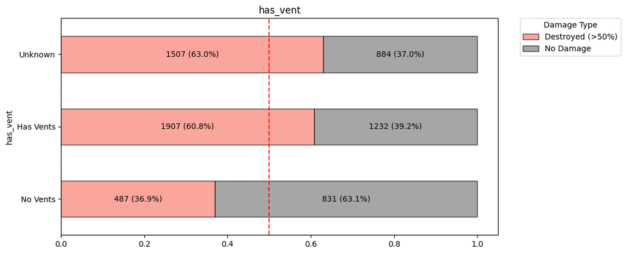

```
Feature: has_vent_screen
✅ Moderate association with Damage (Cramér's V:0.211)
```

[3 more figures not shown]

```python
categorical_features = X_train_origin.select_dtypes(['category', 'datetime']).columns

target_categorical_features = []
for col in X_train_origin.select_dtypes(['category', 'datetime']).columns:
    if X_train_origin[col].nunique() <= 10:
        target_categorical_features.append(col)

for col in target_categorical_features:
    analyze_categorical_feature(train_df, col)
```

### Final features selection

In summary, the features selected for modeling include `structure_type`, `roof_construction`, `exterior_siding`, `has_vent`, `has_vent_screen`, `incident_start_month`, `incident_start_year`.

```python
selected_features = ['structure_type', 'roof_construction', 'exterior_siding', 'has_vent', 'has_vent_screen', 'incident_start_month', 'incident_start_year']
summarize_columns(X_train_origin[selected_features])
```

|  | col_name | unique_values | dtype | example | missing% |
| --- | --- | --- | --- | --- | --- |
| 0 | structure_type | 8 | category | Utility Misc Structure | 0.0 |
| 1 | roof_construction | 8 | category | Fire Resistant | 0.0 |
| 2 | exterior_siding | 9 | category | Fire Resistant | 0.0 |
| 3 | has_vent | 3 | category | Unknown | 0.0 |
| 4 | has_vent_screen | 3 | category | Unknown | 0.0 |
| 5 | incident_start_month | 10 | category | 12 | 0.0 |
| 6 | incident_start_year | 13 | int64 | 2017 | 0.0 |

### Encode features and targets

- Convert categorical features into one-hot encoded dummy variables and drop the first column to avoid multicollinearity for Linear and Logistic Regression models
- Standardize continuous numerical features to ensure they are on a comparable scale with binary variables, which improves model interpretability and performance
- The final encoded datasets are `X_train`, `X_test`, `y_train`, and `y_test`

```python
X, baseline_info, feature_mapping = encode_features(X_origin, selected_features, drop_first=True)
y = encode_target(y_origin)
X_train, X_test, y_train, y_test = train_test_split(X, y, test_size=0.3, random_state=0)
```

```python
damage_cases_df = X_train.sum().reset_index()
damage_cases_df.columns = ['feature', 'true_cases']
damage_cases_df.head()
damage_cases_df.loc[damage_cases_df['feature'] == 'incident_start_year', 'true_cases'] = 0
damage_cases_df
```

|  | feature | true_cases |
| --- | --- | --- |
| 0 | structure_type_Mobile Home Double/Triple Wide | 356.0 |
| 1 | structure_type_Mobile Home Single Wide | 170.0 |
| 2 | structure_type_Motor Home | 90.0 |
| 3 | structure_type_Multi Family Residence | 94.0 |
| 4 | structure_type_Single Family Residence Multi S... | 1504.0 |
| 5 | structure_type_Single Family Residence Single ... | 2459.0 |
| 6 | structure_type_Utility Misc Structure | 1912.0 |
| 7 | roof_construction_Combustible | 86.0 |
| 8 | roof_construction_Fire Resistant | 654.0 |
| 9 | roof_construction_Metal | 1053.0 |
| 10 | roof_construction_Other | 131.0 |
| 11 | roof_construction_Tile | 565.0 |
| 12 | roof_construction_Unknown | 1197.0 |
| 13 | roof_construction_Wood | 71.0 |
| 14 | exterior_siding_Fire Resistant | 318.0 |
| 15 | exterior_siding_Ignition Resistant | 463.0 |
| 16 | exterior_siding_Metal | 265.0 |
| 17 | exterior_siding_Other | 71.0 |
| 18 | exterior_siding_Stucco Brick Cement | 1832.0 |
| 19 | exterior_siding_Unknown | 1189.0 |
| 20 | exterior_siding_Vinyl | 70.0 |
| 21 | exterior_siding_Wood | 1517.0 |
| 22 | has_vent_No Vents | 1318.0 |
| 23 | has_vent_Unknown | 2391.0 |
| 24 | has_vent_screen_Unknown | 2391.0 |
| 25 | has_vent_screen_Unscreened | 1447.0 |
| 26 | incident_start_month_2 | 7.0 |
| 27 | incident_start_month_5 | 9.0 |
| 28 | incident_start_month_6 | 60.0 |
| 29 | incident_start_month_7 | 681.0 |
| 30 | incident_start_month_8 | 992.0 |
| 31 | incident_start_month_9 | 1091.0 |
| 32 | incident_start_month_10 | 741.0 |
| 33 | incident_start_month_11 | 1456.0 |
| 34 | incident_start_month_12 | 151.0 |
| 35 | incident_start_year | 0.0 |

```python
baseline_info
```

|  | original_feature | baseline_category | true_cases |
| --- | --- | --- | --- |
| 0 | structure_type | structure_type_Commercial Building | 379 |
| 1 | roof_construction | roof_construction_Asphalt | 4449 |
| 2 | exterior_siding | exterior_siding_Combustible | 1597 |
| 3 | has_vent | has_vent_Has Vents | 4520 |
| 4 | has_vent_screen | has_vent_screen_Screened | 4328 |
| 5 | incident_start_month | incident_start_month_1 | 2391 |

# 2. Predictive Modeling: Linear Regression

A linear regression model is first used as a baseline to understand the relationship between features and the target variable. Despite being a simple model, it provides interpretability through its coefficients and serves as a useful reference point for more complex models.

## Model Training

```python
linreg = LinearRegression()
linreg.fit(X_train, y_train)
linreg_train_pred = linreg.predict(X_train)
linreg_test_pred = linreg.predict(X_test)
```

## Model Coefficients

Since linear regression is designed to predict continuous target values, applying it to a binary classification task using a threshold of 0.5 changes how the coefficients should be interpreted. In this context, it is not appropriate to interpret the coefficients as indicating how much the target value changes per unit increase in a feature. Instead, the focus should be on the sign (positive or negative) of the coefficient, which indicates the direction of the relationship with the target, and the magnitude, which reflects the relative strength of the influence compared to other features.

To better assess feature influence in this case, 0.2 (median value) and 0.4 (75th percentile) are used as reference points to distinguish between weak, moderate, and strong influences.

**1. Structure type**

- Compared to `Commercial Buildings`, only `Motor Homes` show a moderate positive relationship with damage, meaning they are more likely to be damaged. Other structure types have similar risk levels to the baseline, with little difference.

**2. Roof construction**

- Compared to `Asphalt` roofs (baseline), `Fire Resistant`, `Combustible`, and `Unknown` types are linked to lower fire damage risk. Other categories show similar risk levels to `Asphalt`.

**3. Incident start year**

- The risk of severe damage decreases in more recent years, which likely reflects improvements in firefighting capabilities, early warning systems, and overall disaster response efforts.
- Since `incident_start_year` is a continuous feature and has been standardized, this effect reflects change per standard deviation increase in year (rather than per calendar year), allowing more meaningful comparison with other binary features.

**4. Incident start month**

- Compared to January, all other months show a lower risk of damage. Months like June, November, December, and February have the lowest risk. However, months like February and May have very few samples, which can make the coefficients unreliable. Merging months with low sample sizes might help improve model performance.

**5. Has vent screen**  
**6. Has vent**

- There’s no big difference between categories.

**7. Exterior siding**

- Overall, `Ignition Resistant`, `Fire Resistant`, and `Combustible` siding types are linked to a higher chance of damage. On the other hand, `Wood` and `Unknown` siding types seem to have a lower risk.

Notably, some of these findings differ from what we observed in the interaction plots in the earlier section. For example, features like `Fire Resistant`, `Wood`, `Combustible`, and `Asphalt` appeared to be associated with more damage in the charts. However, the linear regression coefficients suggest a different conclusion. One possible reason is that the high damage rates seen in those categories might have been influenced by other features that often appear together. In other words, it’s not the material itself causing the damage risk, but other risk factors that tend to co-occur with them. By controlling for other variables in the linear regression model, the effect of each feature becomes clearer, leading to different insights.

```python
linreg_coef = gen_model_coefficients(input_coef=linreg.coef_,
                                     input_features=X_train.columns,
                                     feature_mapping_df=feature_mapping,
                                     coef_name='coef')
linreg_coef = linreg_coef.merge(damage_cases_df, on='feature')
linreg_coef = linreg_coef.merge(baseline_info[['original_feature', 'baseline_category']], on='original_feature', how='left')
abs(linreg_coef['coef']).describe()
```

```
count    36.000000
mean      0.262892
std       0.170708
min       0.023300
25%       0.118700
50%       0.251400
75%       0.412025
max       0.551000
Name: coef, dtype: float64
```

```python
linreg_coef
# [abs(linreg_coef['coef']) > 0.2]
```

|  | original_feature | feature | coef | true_cases | baseline_category |
| --- | --- | --- | --- | --- | --- |
| 0 | structure_type | structure_type_Motor Home | 0.3081 | 90.0 | structure_type_Commercial Building |
| 1 | structure_type | structure_type_Mobile Home Single Wide | 0.1925 | 170.0 | structure_type_Commercial Building |
| 2 | structure_type | structure_type_Mobile Home Double/Triple Wide | 0.1529 | 356.0 | structure_type_Commercial Building |
| 3 | structure_type | structure_type_Utility Misc Structure | 0.1046 | 1912.0 | structure_type_Commercial Building |
| 4 | structure_type | structure_type_Single Family Residence Single ... | 0.0717 | 2459.0 | structure_type_Commercial Building |
| 5 | structure_type | structure_type_Single Family Residence Multi S... | -0.0233 | 1504.0 | structure_type_Commercial Building |
| 6 | structure_type | structure_type_Multi Family Residence | -0.1556 | 94.0 | structure_type_Commercial Building |
| 7 | roof_construction | roof_construction_Wood | 0.1661 | 71.0 | roof_construction_Asphalt |
| 8 | roof_construction | roof_construction_Metal | 0.0341 | 1053.0 | roof_construction_Asphalt |
| 9 | roof_construction | roof_construction_Other | -0.0958 | 131.0 | roof_construction_Asphalt |
| 10 | roof_construction | roof_construction_Tile | -0.1912 | 565.0 | roof_construction_Asphalt |
| 11 | roof_construction | roof_construction_Fire Resistant | -0.2104 | 654.0 | roof_construction_Asphalt |
| 12 | roof_construction | roof_construction_Combustible | -0.2522 | 86.0 | roof_construction_Asphalt |
| 13 | roof_construction | roof_construction_Unknown | -0.3463 | 1197.0 | roof_construction_Asphalt |
| 14 | incident_start_year | incident_start_year | -0.2515 | 0.0 | NaN |
| 15 | incident_start_month | incident_start_month_9 | -0.3735 | 1091.0 | incident_start_month_1 |
| 16 | incident_start_month | incident_start_month_5 | -0.4178 | 9.0 | incident_start_month_1 |
| 17 | incident_start_month | incident_start_month_10 | -0.4368 | 741.0 | incident_start_month_1 |
| 18 | incident_start_month | incident_start_month_7 | -0.4501 | 681.0 | incident_start_month_1 |
| 19 | incident_start_month | incident_start_month_8 | -0.4680 | 992.0 | incident_start_month_1 |
| 20 | incident_start_month | incident_start_month_6 | -0.5316 | 60.0 | incident_start_month_1 |
| 21 | incident_start_month | incident_start_month_11 | -0.5334 | 1456.0 | incident_start_month_1 |
| 22 | incident_start_month | incident_start_month_12 | -0.5469 | 151.0 | incident_start_month_1 |
| 23 | incident_start_month | incident_start_month_2 | -0.5510 | 7.0 | incident_start_month_1 |
| 24 | has_vent_screen | has_vent_screen_Unknown | 0.1187 | 2391.0 | has_vent_screen_Screened |
| 25 | has_vent_screen | has_vent_screen_Unscreened | -0.0362 | 1447.0 | has_vent_screen_Screened |
| 26 | has_vent | has_vent_Unknown | 0.1187 | 2391.0 | has_vent_Has Vents |
| 27 | has_vent | has_vent_No Vents | -0.1206 | 1318.0 | has_vent_Has Vents |
| 28 | exterior_siding | exterior_siding_Ignition Resistant | 0.0552 | 463.0 | exterior_siding_Combustible |
| 29 | exterior_siding | exterior_siding_Fire Resistant | -0.0387 | 318.0 | exterior_siding_Combustible |
| 30 | exterior_siding | exterior_siding_Other | -0.2513 | 71.0 | exterior_siding_Combustible |
| 31 | exterior_siding | exterior_siding_Stucco Brick Cement | -0.2542 | 1832.0 | exterior_siding_Combustible |
| 32 | exterior_siding | exterior_siding_Metal | -0.2967 | 265.0 | exterior_siding_Combustible |
| 33 | exterior_siding | exterior_siding_Vinyl | -0.3657 | 70.0 | exterior_siding_Combustible |
| 34 | exterior_siding | exterior_siding_Wood | -0.4101 | 1517.0 | exterior_siding_Combustible |
| 35 | exterior_siding | exterior_siding_Unknown | -0.5326 | 1189.0 | exterior_siding_Combustible |

## Model Evaluation - Training Set

- A threshold of 0.5 is used to convert the predicted continuous values into binary class labels: values >= 0.5 are classified as 1, and values < 0.5 as 0.
- Accuracy, precision, recall, and F1-score all exceed 0.8, indicating strong model performance on the training set in predicting the target variable y using this threshold.

```python
linreg_train_result = gen_prediction_comparison(y_actual=y_train,
                                          y_pred=linreg_train_pred,
                                          set_type='train',
                                          threshold=0.5)
linreg_train_result[:10]
```

|  | y_train_actual | y_train_pred | y_train_pred_class |
| --- | --- | --- | --- |
| 0 | 1 | 1.013305 | 1 |
| 1 | 1 | 0.884063 | 1 |
| 2 | 0 | 0.305369 | 0 |
| 3 | 0 | 0.252069 | 0 |
| 4 | 0 | 0.345356 | 0 |
| 5 | 0 | 0.282375 | 0 |
| 6 | 0 | 0.311900 | 0 |
| 7 | 1 | 0.439399 | 0 |
| 8 | 1 | 0.868879 | 1 |
| 9 | 1 | 0.536534 | 1 |

```python
print("Linear Regression Model Performance on Tranining Set")
classification_evaluation(y_actual=linreg_train_result['y_train_actual'], y_pred=linreg_train_result['y_train_pred_class'])
```

```
Linear Regression Model Performance on Tranining Set
Accuracy Score : 0.819
Precision Score: 0.86
Recall Score   : 0.815
F1 Score       : 0.837

Confusion Matrix:
```

|  | Predicted: No Damage (0) | Predicted: Destroyed (1) |
| --- | --- | --- |
| Actual: No Damage (0) | 2431 | 516 |
| Actual: Destroyed (1) | 722 | 3179 |

```
Classification Report:
              precision    recall  f1-score   support

           0       0.77      0.82      0.80      2947
           1       0.86      0.81      0.84      3901

    accuracy                           0.82      6848
   macro avg       0.82      0.82      0.82      6848
weighted avg       0.82      0.82      0.82      6848
```

## Model Evaluation Comparison – Training vs Test Set

- The same 0.5 threshold is applied to the test dataset to convert predicted values into binary labels.
- The accuracy, precision, recall, and F1-score on the test set are also all above 0.8 and closely aligned with the training set metrics.
- This suggests that the model performs consistently well on both datasets, and that the strong performance is not due to overfitting or memorization, but rather reflects genuine generalization ability.

```python
linreg_test_result = gen_prediction_comparison(y_actual=y_test,
                                         y_pred=linreg_test_pred,
                                         set_type='test',
                                         threshold=0.5)
```

```python
print("Linear Regression Model Performance on Tranining Set")
classification_evaluation(y_actual=linreg_train_result['y_train_actual'], y_pred=linreg_train_result['y_train_pred_class'])

print("Linear Regression Model Performance on Test Set")
classification_evaluation(y_actual=linreg_test_result['y_test_actual'], y_pred=linreg_test_result['y_test_pred_class'])
```

```
Linear Regression Model Performance on Tranining Set
Accuracy Score : 0.819
Precision Score: 0.86
Recall Score   : 0.815
F1 Score       : 0.837

Confusion Matrix:
```

|  | Predicted: No Damage (0) | Predicted: Destroyed (1) |
| --- | --- | --- |
| Actual: No Damage (0) | 2431 | 516 |
| Actual: Destroyed (1) | 722 | 3179 |

```
Classification Report:
              precision    recall  f1-score   support

           0       0.77      0.82      0.80      2947
           1       0.86      0.81      0.84      3901

    accuracy                           0.82      6848
   macro avg       0.82      0.82      0.82      6848
weighted avg       0.82      0.82      0.82      6848

Linear Regression Model Performance on Test Set
Accuracy Score : 0.819
Precision Score: 0.855
Recall Score   : 0.826
F1 Score       : 0.84

Confusion Matrix:
```

|  | Predicted: No Damage (0) | Predicted: Destroyed (1) |
| --- | --- | --- |
| Actual: No Damage (0) | 1012 | 237 |
| Actual: Destroyed (1) | 294 | 1392 |

```
Classification Report:
              precision    recall  f1-score   support

           0       0.77      0.81      0.79      1249
           1       0.85      0.83      0.84      1686

    accuracy                           0.82      2935
   macro avg       0.81      0.82      0.82      2935
weighted avg       0.82      0.82      0.82      2935
```

## Model Evaluation Comparison – Single vs Repeated train/test splits

- To simulate cross-validation, five random 70/30 train/test splits using different random states are generated. For each split, a linear regression model was trained and evaluated on the test set, and the average scores for accuracy, precision, recall, and F1-score were computed.
- The results show that the average performance over the five random splits remains consistently strong, with all key metrics above 0.8. These scores are nearly identical to those obtained from the single train/test split, indicating that the model’s performance is stable and not highly sensitive to data partitioning.

```python
random_states = [1, 3, 100, 9440, 3950]
accuracy_scores = []
precision_scores = []
recall_scores = []
f1_scores = []

for random_state in random_states:
    model = LinearRegression()
    X_train, X_test, y_train, y_test = train_test_split(X, y, test_size=0.3, random_state=random_state)
    model.fit(X_train, y_train)
    y_test_pred = model.predict(X_test)
    y_test_pred_class = np.array([1 if num >= 0.5 else 0 for num in y_test_pred])
    accuracy_scores.append(accuracy_score(y_test, y_test_pred_class))
    precision_scores.append(precision_score(y_test, y_test_pred_class))
    recall_scores.append(recall_score(y_test, y_test_pred_class))
    f1_scores.append(f1_score(y_test, y_test_pred_class))

print("Linear Regression Average Performance Over 5 Random 70/30 Train/Test Splits")
print("Accuracy Score :", round(np.mean(accuracy_scores), 3))
print("Precision Score:", round(np.mean(precision_scores), 3))
print("Recall Score   :", round(np.mean(recall_scores), 3))
print("F1 Score       :", round(np.mean(f1_scores), 3))
```

```
Linear Regression Average Performance Over 5 Random 70/30 Train/Test Splits
Accuracy Score : 0.82
Precision Score: 0.867
Recall Score   : 0.812
F1 Score       : 0.838
```

```python
print("Linear Regression Model Performance on Test Set (Single 70/30 Split")
classification_evaluation(y_actual=linreg_test_result['y_test_actual'], y_pred=linreg_test_result['y_test_pred_class'])
```

```
Linear Regression Model Performance on Test Set (Single 70/30 Split
Accuracy Score : 0.819
Precision Score: 0.855
Recall Score   : 0.826
F1 Score       : 0.84

Confusion Matrix:
```

|  | Predicted: No Damage (0) | Predicted: Destroyed (1) |
| --- | --- | --- |
| Actual: No Damage (0) | 1012 | 237 |
| Actual: Destroyed (1) | 294 | 1392 |

```
Classification Report:
              precision    recall  f1-score   support

           0       0.77      0.81      0.79      1249
           1       0.85      0.83      0.84      1686

    accuracy                           0.82      2935
   macro avg       0.81      0.82      0.82      2935
weighted avg       0.82      0.82      0.82      2935
```

# 3. Predictive Modeling: Logistic Regression

Logistic regression is applied as a classification model to estimate the probability of severe damage. This model provides a balance between interpretability and predictive performance.

## Model Training

```python
logreg = LogisticRegression(max_iter=3000)
logreg.fit(X_train, y_train)
logreg_train_pred = logreg.predict(X_train)
logreg_test_pred = logreg.predict(X_test)
```

## Model Coefficients

**1. Structure Type**

- Compared to `Commercial Building`, structures like `Motor Home` and `Mobile Home (Single/Double/Triple Wide)` are associated with **3–5× higher odds** of severe damage. This suggests these types are more vulnerable to wildfire destruction due to lighter construction or less strict safety standards.
- `Utility Misc Structure` shows a moderately increased risk (1.85x). These buildings are typically non-residential, may lack fire protection, and often store flammable materials. They are also more likely located in open areas without defensible space or landscaping, increasing fire exposure.
- `Multi-Family Residence` has a lower risk (0.5×). This may be due to tighter fire safety codes, standardized construction, and professional maintenance in high-occupancy buildings.
- `Single-Family Residence` types (single vs. multi-story) show mixed results but both are close to the baseline.

**2. Roof Construction**

**3. Incident Start Year**

- The odds ratio is 0.21, indicating that more recent incidents are associated with substantially lower risk of severe damage.

**4. Incident Start Month**

**5. Has Vent Screen**  
**6. Has Vent**

**7. Exterior Siding**

Worthy to note that some features show different directions in relation to the target variable when comparing the previous linear regression model and the logistic regression results. For example, `Combustible` roof construction types are associated with 1.06× higher odds of severe damage in the logistic regression, buy its coefficients in the linear regression were around -0.25. This difference may be due to small sample sizes(86), which can distort linear regression coefficients.

In summary, since the target variable is binary, logistic regression is more appropriate for interpreting the effect of categorical features on severe damage risk.

```python
logreg_coef = gen_model_coefficients(input_coef=logreg.coef_,
                                     input_features=X_train.columns,
                                     feature_mapping_df=feature_mapping,
                                     coef_name='coef')

logreg_coef['odds_ratio'] = np.exp(logreg_coef['coef'])
logreg_coef = logreg_coef.merge(damage_cases_df, on='feature')
logreg_coef.merge(baseline_info[['original_feature', 'baseline_category']], on='original_feature', how='left')
```

|  | original_feature | feature | coef | odds_ratio | true_cases | baseline_category |
| --- | --- | --- | --- | --- | --- | --- |
| 0 | structure_type | structure_type_Motor Home | 1.7377 | 5.684255 | 90.0 | structure_type_Commercial Building |
| 1 | structure_type | structure_type_Mobile Home Double/Triple Wide | 1.2490 | 3.486854 | 356.0 | structure_type_Commercial Building |
| 2 | structure_type | structure_type_Mobile Home Single Wide | 1.2435 | 3.467729 | 170.0 | structure_type_Commercial Building |
| 3 | structure_type | structure_type_Utility Misc Structure | 0.6310 | 1.879489 | 1912.0 | structure_type_Commercial Building |
| 4 | structure_type | structure_type_Single Family Residence Single ... | 0.3904 | 1.477572 | 2459.0 | structure_type_Commercial Building |
| 5 | structure_type | structure_type_Single Family Residence Multi S... | -0.1829 | 0.832851 | 1504.0 | structure_type_Commercial Building |
| 6 | structure_type | structure_type_Multi Family Residence | -0.7518 | 0.471517 | 94.0 | structure_type_Commercial Building |
| 7 | roof_construction | roof_construction_Wood | 0.6758 | 1.965605 | 71.0 | roof_construction_Asphalt |
| 8 | roof_construction | roof_construction_Metal | 0.1716 | 1.187203 | 1053.0 | roof_construction_Asphalt |
| 9 | roof_construction | roof_construction_Combustible | 0.0610 | 1.062899 | 86.0 | roof_construction_Asphalt |
| 10 | roof_construction | roof_construction_Fire Resistant | -0.4000 | 0.670320 | 654.0 | roof_construction_Asphalt |
| 11 | roof_construction | roof_construction_Other | -0.6025 | 0.547441 | 131.0 | roof_construction_Asphalt |
| 12 | roof_construction | roof_construction_Tile | -1.0384 | 0.354021 | 565.0 | roof_construction_Asphalt |
| 13 | roof_construction | roof_construction_Unknown | -2.2554 | 0.104832 | 1197.0 | roof_construction_Asphalt |
| 14 | incident_start_year | incident_start_year | -1.5741 | 0.207194 | 0.0 | NaN |
| 15 | incident_start_month | incident_start_month_2 | -1.0243 | 0.359048 | 7.0 | incident_start_month_1 |
| 16 | incident_start_month | incident_start_month_5 | -1.1748 | 0.308881 | 9.0 | incident_start_month_1 |
| 17 | incident_start_month | incident_start_month_6 | -2.0664 | 0.126641 | 60.0 | incident_start_month_1 |
| 18 | incident_start_month | incident_start_month_9 | -2.1637 | 0.114899 | 1091.0 | incident_start_month_1 |
| 19 | incident_start_month | incident_start_month_7 | -2.3083 | 0.099430 | 681.0 | incident_start_month_1 |
| 20 | incident_start_month | incident_start_month_8 | -2.6664 | 0.069502 | 992.0 | incident_start_month_1 |
| 21 | incident_start_month | incident_start_month_10 | -3.0449 | 0.047601 | 741.0 | incident_start_month_1 |
| 22 | incident_start_month | incident_start_month_11 | -3.2954 | 0.037053 | 1456.0 | incident_start_month_1 |
| 23 | incident_start_month | incident_start_month_12 | -3.8170 | 0.021994 | 151.0 | incident_start_month_1 |
| 24 | has_vent_screen | has_vent_screen_Unknown | 1.2457 | 3.475367 | 2391.0 | has_vent_screen_Screened |
| 25 | has_vent_screen | has_vent_screen_Unscreened | -0.3244 | 0.722961 | 1447.0 | has_vent_screen_Screened |
| 26 | has_vent | has_vent_Unknown | 1.2457 | 3.475367 | 2391.0 | has_vent_Has Vents |
| 27 | has_vent | has_vent_No Vents | -0.3956 | 0.673276 | 1318.0 | has_vent_Has Vents |
| 28 | exterior_siding | exterior_siding_Ignition Resistant | 1.7654 | 5.843909 | 463.0 | exterior_siding_Combustible |
| 29 | exterior_siding | exterior_siding_Fire Resistant | -0.7970 | 0.450679 | 318.0 | exterior_siding_Combustible |
| 30 | exterior_siding | exterior_siding_Stucco Brick Cement | -2.3831 | 0.092264 | 1832.0 | exterior_siding_Combustible |
| 31 | exterior_siding | exterior_siding_Other | -2.5398 | 0.078882 | 71.0 | exterior_siding_Combustible |
| 32 | exterior_siding | exterior_siding_Metal | -2.5687 | 0.076635 | 265.0 | exterior_siding_Combustible |
| 33 | exterior_siding | exterior_siding_Vinyl | -3.0133 | 0.049129 | 70.0 | exterior_siding_Combustible |
| 34 | exterior_siding | exterior_siding_Wood | -3.2381 | 0.039238 | 1517.0 | exterior_siding_Combustible |
| 35 | exterior_siding | exterior_siding_Unknown | -4.5296 | 0.010785 | 1189.0 | exterior_siding_Combustible |

```python
tmp = linreg_coef.merge(logreg_coef[['feature', 'odds_ratio' ]], on=['feature'])
cond1 = (tmp['coef'] < 0) & (tmp['odds_ratio'] > 1)
cond2 = (tmp['coef'] > 0) & (tmp['odds_ratio'] < 1)
tmp[cond1 | cond2]
```

|  | original_feature | feature | coef | true_cases | baseline_category | odds_ratio |
| --- | --- | --- | --- | --- | --- | --- |
| 12 | roof_construction | roof_construction_Combustible | -0.2522 | 86.0 | roof_construction_Asphalt | 1.062899 |